# Practical Machine Learning: Prediction Assignment

Luis Donaldo

2025-07-05

### Overview

This report is part of the final project for the Practical Machine Learning course by Johns Hopkins University on Coursera. The objective of this project is to build a machine learning model that can accurately predict the manner in which individuals performed a set of exercises based on sensor data. The model will be trained using data collected from accelerometers on the belt, forearm, arm, and dumbbell of six participants.

We are required to:

Clean and preprocess the training dataset.

Use the selected model to predict outcomes on the testing dataset.

### Introduction

In recent years, the use of wearable devices and sensors has expanded significantly in the fields of health, sports, and physical rehabilitation. One practical application of this technology is to automatically classify physical activities based on movement patterns.

In this project, we use data collected from multiple body-mounted sensors to predict the “classe” variable, which describes how an activity was performed. The dataset includes measurements like total acceleration, gyroscopic data, and angles from different sensors.

We will follow a machine learning workflow that includes:

Data cleaning and preparation.

Model training and evaluation.

Prediction and performance assessment.

The goal is to develop a model that generalizes well and performs accurately on unseen data.

### Data Loading and Cleaning

We used two datasets provided by the course instructors:

pml-training.csv: This dataset contains 19,622 observations and 160 variables. It includes sensor measurements and a target variable classe, which takes values from A to E, representing different exercise classifications.

pml-testing.csv: This dataset contains 20 observations with the same structure as the training set, but without the classe variable. Our final predictions will be made on this dataset.

```r
# Data loading
df_train <- "http://d396qusza40orc.cloudfront.net/predmachlearn/pml-training.csv"
df_test <- "http://d396qusza40orc.cloudfront.net/predmachlearn/pml-testing.csv"

df_train <- read.csv(url(df_train), na.strings = c("NA",""))
df_test  <- read.csv(url(df_test), na.strings = c("NA",""))
```

```r
# Data Cleaning
na_prop <- colMeans(is.na(df_train))
cols_to_keep <- names(na_prop[na_prop < 0.95])
df_train_clean <- df_train[, cols_to_keep]

irrelevant_cols <- c("X", "user_name", "raw_timestamp_part_1", "raw_timestamp_part_2",
                     "cvtd_timestamp", "new_window", "num_window")
df_train_clean <- df_train_clean[, !(names(df_train_clean) %in% irrelevant_cols)]

df_train_clean$classe <- as.factor(df_train_clean$classe)

# Test Dataset
features <- setdiff(names(df_train_clean), "classe")
df_test_clean <- df_test[, features]
```

```r
set.seed(123)
inTrain <- createDataPartition(df_train_clean$classe, p = 0.7, list = FALSE)
training <- df_train_clean[inTrain, ]
testing <- df_train_clean[-inTrain, ]
```

### Correlation Analysis

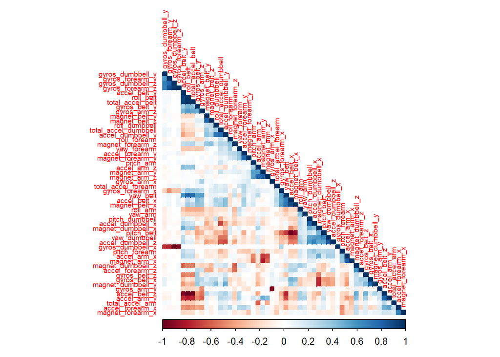

```r
numeric_vars <- sapply(training, is.numeric)
numeric_data <- training[, numeric_vars]

# Calculate Correlation Matrix
cor_matrix <- cor(numeric_data, use = "pairwise.complete.obs")

# Make the plot
corrplot(cor_matrix, method = "color", type = "lower", tl.cex = 0.6, order = "hclust")
```

### Random Forest

```r
set.seed(123)  # para reproducibilidad
rf_model <- randomForest(classe ~ ., data = df_train_clean, ntree = 100, importance = TRUE)

rf_model
```

```
##
## Call:
##  randomForest(formula = classe ~ ., data = df_train_clean, ntree = 100,      importance = TRUE)
##                Type of random forest: classification
##                      Number of trees: 100
## No. of variables tried at each split: 7
##
##         OOB estimate of  error rate: 0.38%
## Confusion matrix:
##      A    B    C    D    E  class.error
## A 5577    1    1    1    0 0.0005376344
## B   17 3773    6    1    0 0.0063207796
## C    0   13 3404    5    0 0.0052600818
## D    0    0   23 3192    1 0.0074626866
## E    0    0    0    5 3602 0.0013861935
```

#### Predictions on Test Data

```r
predictions_test <- predict(rf_model, df_test_clean)
predictions_test
```

```
##  1  2  3  4  5  6  7  8  9 10 11 12 13 14 15 16 17 18 19 20
##  B  A  B  A  A  E  D  B  A  A  B  C  B  A  E  E  A  B  B  B
## Levels: A B C D E
```

### Conclusion

The confusion matrix shows very few misclassifications, with most occurring between nearby classes, which is reasonable in real-world scenarios.